# Master Data Analysis

2024-12-04

This document serves as the master file for data analysis of the replication study, *“How Quick Decisions Illuminate Moral Character.”* The primary objective of this study is to closely mirror the methodology of the original research. Accordingly, the statistical analysis will replicate the 2x2 ANOVA used in the original study, enabling a direct assessment of the main effects of decision speed and moral condition on moral character evaluations, as well as their interaction.

# Data Collection and Analysis

This replication study is part of a series of replication projects conducted in **PSYCH 201a / CSS 204**. Three independent teams replicated the study. To strengthen the confirmatory analysis, we merged the datasets from all three teams. The analysis will be based on both the combined dataset and the individual datasets specific to this team.

# Hypotheses

### Loading required library and data set

```r
library(tidyverse)
library(dplyr)
library(car)
library(emmeans)
library(effectsize)
library(lme4)
# Load the dataset
dat <- read.csv("quick_decisions_combined.csv")  # Read the dataset into a data frame
```

```r
# Count how many trials of each group is kept for combined analysis
trial_count1 <- dat %>%
  group_by(group) %>%
  summarize(row_count = n())


# View the counts
print(trial_count1)
```

```
## # A tibble: 3 × 2
##   group row_count
##   <int>     <int>
## 1     1       100
## 2     2        96
## 3     3        95
```

```r
# cleaned_data <- dat %>%
#   # Step 1: Filter out missing values
#   mutate(is_complete = complete.cases(.)) %>%
#   filter(complete.cases(.))
#
# trial_count2 <- cleaned_data %>%
#   group_by(group) %>%
#   summarize(row_count = n())
#
# print(trial_count2)
```

## Implement Exclusion Criteria: For participant with incomplete answers and lack of variance

```r
# Process the dataset
cleaned_data <- dat %>%
  # Step 1: Filter out missing values
  mutate(is_complete = complete.cases(.)) %>%
  filter(complete.cases(.)) %>%

  # Step 2: Calculate variance for Justin and Nate
  rowwise() %>%
  mutate(
    justin_variance = var(c(Justin_Q2, Justin_Q3, Justin_Q4), na.rm = TRUE), # Variance for Justin
    nate_variance = var(c(Nate_Q2, Nate_Q3, Nate_Q4), na.rm = TRUE)          # Variance for Nate
  ) %>%
  ungroup() %>%

  # Step 3: Filter out participants based on variance criteria
  filter(!(justin_variance == 0 | nate_variance == 0)) %>%

  # Step 4: Drop intermediate columns used for exclusion
  select(-is_complete, -justin_variance, -nate_variance)

# Step 5: Calculate exclusion counts
  na_exclusions_count <- nrow(dat) - nrow(dat %>% filter(complete.cases(.))) # Count rows with missing values
  variance_exclusions_count <- nrow(dat %>% filter(complete.cases(.))) - nrow(cleaned_data) # Count participants excluded for lack of variance
  total_exclusions <- na_exclusions_count + variance_exclusions_count  # Calculate total exclusions

# Step 6: Create a summary table of exclusions
exclusions_summary <- tibble(
  Exclusion_Criteria = c(
    "Missing values (NA)",
    "Lack of variance",
    "Total exclusions"
  ),
  Count = c(
    na_exclusions_count,
    variance_exclusions_count,
    total_exclusions
  )
)

# Display the table
print(exclusions_summary)
```

```
## # A tibble: 3 × 2
##   Exclusion_Criteria  Count
##   <chr>               <int>
## 1 Missing values (NA)    84
## 2 Lack of variance      107
## 3 Total exclusions      191
```

```r
# Count how many trials of each group is kept for combined analysis
trial_count <- cleaned_data %>%
  group_by(group) %>%
  summarize(row_count = n())

# Count how many trials is kept for each condition in combined analysis
condition_combined_counts <- cleaned_data %>%
  group_by(condition) %>%
  summarize(count = n())

# View the counts
print(trial_count)
```

```
## # A tibble: 3 × 2
##   group row_count
##   <int>     <int>
## 1     1         8
## 2     2        42
## 3     3        50
```

```r
print(condition_combined_counts)
```

```
## # A tibble: 2 × 2
##   condition count
##   <chr>     <int>
## 1 immoral      66
## 2 moral        34
```

## Manipulation Check for Combined Dataset

Groups the data by condition and provides a clear comparison of how the participants perceived Justin’s decision speed and Nate’s decision speed across the two conditions. (Note: the mean should be different between Justin and Nate but it should be similar across condition).

Then we will determine whether there is a statistically significant difference in the mean scores of Justin’s speed and Nate’s speed.

```r
# Add Participant_ID column and make it the first column
cleaned_data <- cleaned_data %>%
  mutate(Participant_ID = row_number()) %>%
  select(Participant_ID, everything())
```

```r
#Summarize the decision speed columns for comparison

manipulation_stats <- cleaned_data %>%
  group_by(condition) %>%  # Group data by the 'condition' column
  summarize(
    mean_speed_justin = mean(Justin_Q1),  # Mean of Justin's speed
    mean_speed_nate = mean(Nate_Q1)     # Mean of Nate's speed
  )


# Paired t-test for Justin's and Nate's speeds for checking whether the manipulation was successful or not
manipulation_combined_t_test <- t.test(
  cleaned_data$Justin_Q1,
  cleaned_data$Nate_Q1,
  paired = TRUE
)

print(manipulation_combined_t_test)
```

```
##
##  Paired t-test
##
## data:  cleaned_data$Justin_Q1 and cleaned_data$Nate_Q1
## t = 11.07, df = 99, p-value < 2.2e-16
## alternative hypothesis: true mean difference is not equal to 0
## 95 percent confidence interval:
##  2.027253 2.912747
## sample estimates:
## mean difference
##            2.47
```

### Perceived Decision Speed Across Condition [**Not Necessary**]

Upon reviewing the descriptive statistics using **‘manipulation_stats’**, we observed a potential mean difference in perceived decision speed for Nate across conditions (moral vs. immoral). Out of curiosity, we decided to conduct a statistical test to explore whether this observed difference is significant.

Please note that this analysis is conducted purely for exploratory purposes and is not part of the original study design. The results should be interpreted cautiously and are not intended to inform the main findings of the study.

```r
# Independent t-tests for moral vs immoral condition on Justin's speed & Nate's speed
t_test_justin <- t.test(
  Justin_Q1 ~ condition,
  data = cleaned_data,
  var.equal = TRUE
)

t_test_nate <- t.test(
  Nate_Q1 ~ condition,
  data = cleaned_data,
  var.equal = TRUE
)

print(t_test_justin)
```

```
##
##  Two Sample t-test
##
## data:  Justin_Q1 by condition
## t = 0.78933, df = 98, p-value = 0.4318
## alternative hypothesis: true difference in means between group immoral and group moral is not equal to 0
## 95 percent confidence interval:
##  -0.6005176  1.3937440
## sample estimates:
## mean in group immoral   mean in group moral
##              4.484848              4.088235
```

```r
print(t_test_nate)
```

```
##
##  Two Sample t-test
##
## data:  Nate_Q1 by condition
## t = 1.9092, df = 98, p-value = 0.05916
## alternative hypothesis: true difference in means between group immoral and group moral is not equal to 0
## 95 percent confidence interval:
##  -0.02092792  1.08331651
## sample estimates:
## mean in group immoral   mean in group moral
##              2.060606              1.529412
```

## Confirmatory Analysis for Combined Dataset: 2x2 Anova

**Objective** : The aim of this analysis is to perform a **2 (moral condition: moral vs. immoral) x 2 (decision speed: quick vs. slow)** repeated-measures ANOVA to compare group means for moral character evaluations of Justin and Nate.

### Step 1: Calculate Average Scores for Justin and Nate

```r
character_eval_combined <- cleaned_data %>%
  mutate(
    # Calculate the average score for Justin across selected questions
    quick_justin_score = rowMeans(select(., Justin_Q2, Justin_Q3, Justin_Q4)),
    # Calculate the average score for Nate across selected questions
    slow_nate_score = rowMeans(select(., Nate_Q2, Nate_Q3, Nate_Q4))
  )
```

### Step 2: Summarize Average Scores by Condition

Group data by condition for comparison of Justin’s moral character evaluation and Nate’s character evaluation across condition

**[Note for ERI]: I think you can use this to create the plot**

```r
 character_eval_combined_stats <- character_eval_combined %>%
  group_by(condition) %>%  # Group data by the 'condition' column
  summarize(
    mean_justin = mean(quick_justin_score), # Mean of Justin's character evaluation
    mean_nate = mean(slow_nate_score)     # Mean of Nate's character evaluation
  )

print(character_eval_combined_stats)  # View summarized data
```

```
## # A tibble: 2 × 3
##   condition mean_justin mean_nate
##   <chr>           <dbl>     <dbl>
## 1 immoral          3.08      4.31
## 2 moral            5.89      4.61
```

### Step 3: Reshape Data for ANOVA

```r
character_eval_combined_long <- character_eval_combined %>%
  pivot_longer(
    cols = c(quick_justin_score, slow_nate_score), # Select the new columns
    names_to = "person",                           # Create a column for person
    values_to = "score"                            # Create a column for scores
  ) %>%
  mutate(
    person = ifelse(person == "quick_justin_score", "Justin", "Nate") # Relabel person column
  )  %>%
  select(Participant_ID, condition, person, score) # Keep only essential columns


# View the reshaped data
head(character_eval_combined_long)
```

```
## # A tibble: 6 × 4
##   Participant_ID condition person score
##            <int> <chr>     <chr>  <dbl>
## 1              1 immoral   Justin  1.67
## 2              1 immoral   Nate    3.67
## 3              2 moral     Justin  3.33
## 4              2 moral     Nate    4
## 5              3 immoral   Justin  3.33
## 6              3 immoral   Nate    3.67
```

### Step 4: Run Repeated-Measures ANOVA

```r
anova_combined <- aov(score ~ condition * person + Error(Participant_ID/person), data = character_eval_combined_long)

# View the summary
summary(anova_combined)
```

```
##
## Error: Participant_ID
##           Df   Sum Sq  Mean Sq
## condition  1 0.009442 0.009442
##
## Error: Participant_ID:person
##        Df Sum Sq Mean Sq
## person  1  6.612   6.612
##
## Error: Within
##                   Df Sum Sq Mean Sq F value   Pr(>F)
## condition          1 108.62  108.62  108.06  < 2e-16 ***
## person             1   0.67    0.67    0.67    0.414
## condition:person   1  71.09   71.09   70.71 8.83e-15 ***
## Residuals        194 195.02    1.01
## ---
## Signif. codes:  0 '***' 0.001 '**' 0.01 '*' 0.05 '.' 0.1 ' ' 1
```

### Step 5: Conduct Post Hoc Pairwise Comparisons

```r
# Conduct post hoc pairwise comparisons using estimated marginal means
posthoc_results <- emmeans(anova_combined, pairwise ~ condition * person)
```

```
## Note: re-fitting model with sum-to-zero contrasts
```

```
## NOTE: Results are based on intra-block estimates and are biased.
```

```r
print(posthoc_results)
```

```
## $emmeans
##  condition person emmean  SE  df asymp.LCL asymp.UCL
##  immoral   Justin   2.93 NaN NaN       NaN       NaN
##  moral     Justin   5.74 NaN NaN       NaN       NaN
##  immoral   Nate     3.96 NaN NaN       NaN       NaN
##  moral     Nate     4.26 NaN NaN       NaN       NaN
##
## Warning: EMMs are biased unless design is perfectly balanced
## Confidence level used: 0.95
##
## $contrasts
##  contrast                      estimate    SE  df t.ratio p.value
##  immoral Justin - moral Justin   -2.815 0.212 194 -13.296  <.0001
##  immoral Justin - immoral Nate   -1.034 0.301 194  -3.432  0.0040
##  immoral Justin - moral Nate     -1.331 0.327 194  -4.068  0.0004
##  moral Justin - immoral Nate      1.782 0.327 194   5.446  <.0001
##  moral Justin - moral Nate        1.484 0.351 194   4.226  0.0002
##  immoral Nate - moral Nate       -0.297 0.212 194  -1.404  0.4983
##
## P value adjustment: tukey method for comparing a family of 4 estimates
```

### Step 6: Compute the effect size

```r
# Refit the repeated measures model
anova_combined_lmer <- lmer(
  score ~ condition * person + (1 | Participant_ID),
  data = character_eval_combined_long
)

# Calculate partial eta-squared for the mixed-effects model
eta2_combined <- eta_squared(anova_combined_lmer, partial = TRUE)

# Print results
print(eta2_combined)
```

```
## # Effect Size for ANOVA (Type III)
##
## Parameter        | Eta2 (partial) |       95% CI
## ------------------------------------------------
## condition        |           0.44 | [0.32, 1.00]
## person           |       6.52e-04 | [0.00, 1.00]
## condition:person |           0.56 | [0.45, 1.00]
##
## - One-sided CIs: upper bound fixed at [1.00].
```

### Visualization

**Note to Eri: Please look at step 2**

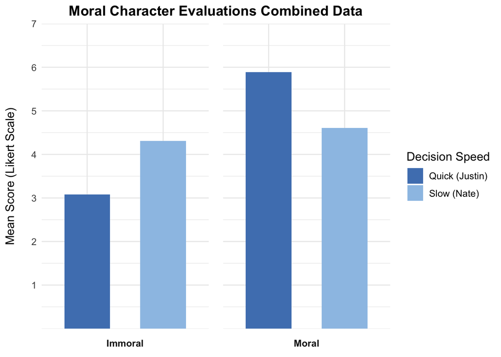

```r
# Updated plot with detailed y-axis tweaks
ggplot(character_eval_combined_long, aes(x = person, y = score, fill = person)) +
  geom_bar(
    stat = "summary",
    fun = "mean",
    position = position_dodge(width = 0.5),  # Columns closer together
    width = 0.6                             # Narrower columns
  ) +
  facet_wrap(
    ~ condition,
    labeller = as_labeller(c(moral = "Moral", immoral = "Immoral")),  # Simplify labels
    strip.position = "bottom"  # Moral/Immoral labels at the bottom
  ) +
  labs(
    title = "Moral Character Evaluations Combined Data",
    y = "Mean Score (Likert Scale)",  # Y-axis label with clarification
    fill = "Decision Speed"  # Legend title
  ) +
  theme_minimal() +
  theme(
    text = element_text(size = 12),
    strip.text = element_text(face = "bold"),
    strip.placement = "outside",  # Push bottom labels outward
    plot.title = element_text(hjust = 0.5, face = "bold", size = 14),  # Centered title
    panel.spacing = unit(1, "lines"),  # Adjust spacing between panels
    axis.title.x = element_blank(),  # Remove x-axis title
    axis.text.x = element_blank(),   # Remove x-axis labels (Justin/Nate)
    axis.title.y = element_text(margin = margin(r = 15))  # Add spacing to y-axis label
  ) +
  scale_fill_manual(
    values = c("Justin" = "#4F81BD", "Nate" = "#9DC3E6"),  # Two shades of blue
    labels = c("Justin" = "Quick (Justin)", "Nate" = "Slow (Nate)")  # Custom legend labels
  ) +
  scale_y_continuous(
    limits = c(0, 7),  # Y-axis limits for Likert scale
    breaks = 1:7,      # Label y-axis by 1's
    expand = c(0, 0)   # No extra space above/below
  )
```

## Confirmatory Analysis of Group 3’s data: 2x2 Anova

This analysis focuses on a subset of the data, specifically Group 3. We will perform the same 2 (moral condition: moral vs. immoral) x 2 (decision speed: quick vs. slow) ANOVA as in the full dataset but restricted to Group 3. This allows us to assess whether the observed effects are consistent within this specific subset.

### Sub setting the data

```r
g3_cleaned_data <- cleaned_data %>%
  filter(group == 3)

# Count how many trials is kept for each condition in combined analysis
g3_condition_counts <- g3_cleaned_data %>%
  group_by(condition) %>%
  summarize(count = n())

print(g3_condition_counts)
```

```
## # A tibble: 2 × 2
##   condition count
##   <chr>     <int>
## 1 immoral      34
## 2 moral        16
```

### Step 1: Calculate Average Scores for Justin and Nate

```r
character_eval_group3 <- g3_cleaned_data %>%
  mutate(
    # Calculate the average score for Justin across selected questions
    quick_justin_score = rowMeans(select(., Justin_Q2, Justin_Q3, Justin_Q4)),
    # Calculate the average score for Nate across selected questions
    slow_nate_score = rowMeans(select(., Nate_Q2, Nate_Q3, Nate_Q4))
  )
```

### Step 2: Summarize Average Scores by Condition

Group data by condition for comparison of Justin’s moral character evaluation and Nate’s character evaluation across condition

**[Note for ERI]: I think you can use this to creat the plot**

```r
 character_eval_group3_stats <- character_eval_group3 %>%
  group_by(condition) %>%  # Group data by the 'condition' column
  summarize(
    mean_justin = mean(quick_justin_score), # Mean of Justin's character evaluation
    mean_nate = mean(slow_nate_score)     # Mean of Nate's character evaluation
  )

print(character_eval_combined_stats)  # View summarized data
```

```
## # A tibble: 2 × 3
##   condition mean_justin mean_nate
##   <chr>           <dbl>     <dbl>
## 1 immoral          3.08      4.31
## 2 moral            5.89      4.61
```

### Step 3: Reshape Data for ANOVA

```r
character_eval_group3_long <- character_eval_group3 %>%
  pivot_longer(
    cols = c(quick_justin_score, slow_nate_score), # Select the new columns
    names_to = "person",                           # Create a column for person
    values_to = "score"                            # Create a column for scores
  ) %>%
  mutate(
    person = ifelse(person == "quick_justin_score", "Justin", "Nate") # Relabel person column
  )  %>%
  select(Participant_ID, condition, person, score) # Keep only essential columns


# View the reshaped data
head(character_eval_group3_long)
```

```
## # A tibble: 6 × 4
##   Participant_ID condition person score
##            <int> <chr>     <chr>  <dbl>
## 1             51 immoral   Justin  2.67
## 2             51 immoral   Nate    4.67
## 3             52 immoral   Justin  3.33
## 4             52 immoral   Nate    5.33
## 5             53 moral     Justin  6.33
## 6             53 moral     Nate    5.33
```

### Step 4: Run Repeated-Measures ANOVA

```r
anova_group3 <- aov(score ~ condition * person + Error(Participant_ID/person), data = character_eval_group3_long)

# View the summary
summary(anova_group3)
```

```
##
## Error: Participant_ID
##           Df  Sum Sq Mean Sq
## condition  1 0.01953 0.01953
##
## Error: Participant_ID:person
##        Df Sum Sq Mean Sq
## person  1  4.336   4.336
##
## Error: Within
##                  Df Sum Sq Mean Sq F value   Pr(>F)
## condition         1  36.22   36.22  36.923 2.60e-08 ***
## person            1   0.08    0.08   0.086     0.77
## condition:person  1  39.64   39.64  40.412 7.34e-09 ***
## Residuals        94  92.20    0.98
## ---
## Signif. codes:  0 '***' 0.001 '**' 0.01 '*' 0.05 '.' 0.1 ' ' 1
```

### Step 5: Conduct Post Hoc Pairwise Comparisons

```r
# Conduct post hoc pairwise comparisons using estimated marginal means
posthoc_group3_results <- emmeans(anova_group3, pairwise ~ condition * person)
```

```
## Note: re-fitting model with sum-to-zero contrasts
```

```
## NOTE: Results are based on intra-block estimates and are biased.
```

```r
print(posthoc_group3_results)
```

```
## $emmeans
##  condition person emmean  SE  df asymp.LCL asymp.UCL
##  immoral   Justin   3.34 NaN NaN       NaN       NaN
##  moral     Justin   6.00 NaN NaN       NaN       NaN
##  immoral   Nate     3.65 NaN NaN       NaN       NaN
##  moral     Nate     3.59 NaN NaN       NaN       NaN
##
## Warning: EMMs are biased unless design is perfectly balanced
## Confidence level used: 0.95
##
## $contrasts
##  contrast                      estimate    SE df t.ratio p.value
##  immoral Justin - moral Justin  -2.6627 0.303 94  -8.792  <.0001
##  immoral Justin - immoral Nate  -0.3126 1.060 94  -0.296  0.9909
##  immoral Justin - moral Nate    -0.2525 1.100 94  -0.230  0.9957
##  moral Justin - immoral Nate     2.3500 1.100 94   2.141  0.1478
##  moral Justin - moral Nate       2.4101 1.140 94   2.117  0.1553
##  immoral Nate - moral Nate       0.0601 0.303 94   0.198  0.9972
##
## P value adjustment: tukey method for comparing a family of 4 estimates
```

### Step 6: Compute the effect size

```r
# Refit the repeated measures model
anova_group3_lmer <- lmer(
  score ~ condition * person + (1 | Participant_ID),
  data = character_eval_group3_long
)

# Calculate partial eta-squared for the mixed-effects model
eta2_group3 <- eta_squared(anova_group3_lmer, partial = TRUE)

# Print results
print(eta2_group3)
```

```
## # Effect Size for ANOVA (Type III)
##
## Parameter        | Eta2 (partial) |       95% CI
## ------------------------------------------------
## condition        |           0.36 | [0.18, 1.00]
## person           |       2.64e-03 | [0.00, 1.00]
## condition:person |           0.56 | [0.40, 1.00]
##
## - One-sided CIs: upper bound fixed at [1.00].
```

### Visualization

**Note to Eri: Please look at step 2**

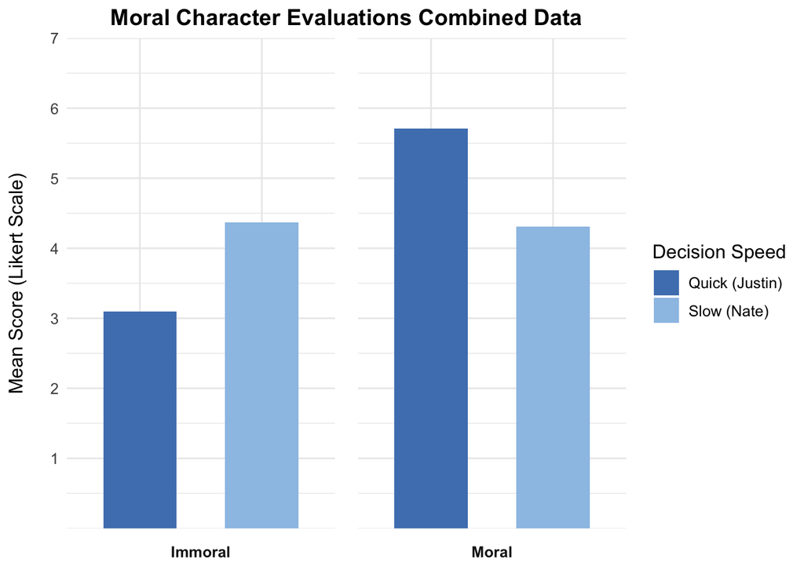

```r
# Updated plot with detailed y-axis tweaks
ggplot(character_eval_group3_long, aes(x = person, y = score, fill = person)) +
  geom_bar(
    stat = "summary",
    fun = "mean",
    position = position_dodge(width = 0.5),  # Columns closer together
    width = 0.6                             # Narrower columns
  ) +
  facet_wrap(
    ~ condition,
    labeller = as_labeller(c(moral = "Moral", immoral = "Immoral")),  # Simplify labels
    strip.position = "bottom"  # Moral/Immoral labels at the bottom
  ) +
  labs(
    title = "Moral Character Evaluations Combined Data",
    y = "Mean Score (Likert Scale)",  # Y-axis label with clarification
    fill = "Decision Speed"  # Legend title
  ) +
  theme_minimal() +
  theme(
    text = element_text(size = 12),
    strip.text = element_text(face = "bold"),
    strip.placement = "outside",  # Push bottom labels outward
    plot.title = element_text(hjust = 0.5, face = "bold", size = 14),  # Centered title
    panel.spacing = unit(1, "lines"),  # Adjust spacing between panels
    axis.title.x = element_blank(),  # Remove x-axis title
    axis.text.x = element_blank(),   # Remove x-axis labels (Justin/Nate)
    axis.title.y = element_text(margin = margin(r = 15))  # Add spacing to y-axis label
  ) +
  scale_fill_manual(
    values = c("Justin" = "#4F81BD", "Nate" = "#9DC3E6"),  # Two shades of blue
    labels = c("Justin" = "Quick (Justin)", "Nate" = "Slow (Nate)")  # Custom legend labels
  ) +
  scale_y_continuous(
    limits = c(0, 7),  # Y-axis limits for Likert scale
    breaks = 1:7,      # Label y-axis by 1's
    expand = c(0, 0)   # No extra space above/below
  )
```